# Lab Week 03: Linear Regression - Part 2

Pouria

1/26/2022

# Lab Prompt

In this lab, we will study regression with 2 predictors, one continuous, and one qualitative, using the Credit data from the package `ISLR`

1. Build a linear model of `balance` as a function of `student` status. Compare with a t-test. What do you conclude?
2. Now build a model with `balance` as a function of `income`. What do you conclude?
3. Next we will build a model with both regressors, `student` status and `income`. 3.a) Plot the data, using different markers for `student status` 3.b) Develop a model corresponding to Figure 3.7 left. Plot the model with the data, as in a). What do you conclude? 3.c) Now develop and plot the full model corresponding to Figure 3.7. Compare the result with those of an ANCOVA analysis. What do you conclude?

# Lab 1

Balance ~ Student

```r
lm.bal_st <- lm(Balance ~ Student)
summary(lm.bal_st)
```

```
##
## Call:
## lm(formula = Balance ~ Student)
##
## Residuals:
##     Min      1Q  Median      3Q     Max
## -876.82 -458.82  -40.87  341.88 1518.63
##
## Coefficients:
##             Estimate Std. Error t value Pr(>|t|)
## (Intercept)   480.37      23.43   20.50  < 2e-16 ***
## StudentYes    396.46      74.10    5.35 1.49e-07 ***
## ---
## Signif. codes:  0 '***' 0.001 '**' 0.01 '*' 0.05 '.' 0.1 ' ' 1
##
## Residual standard error: 444.6 on 398 degrees of freedom
## Multiple R-squared:  0.06709,    Adjusted R-squared:  0.06475
## F-statistic: 28.62 on 1 and 398 DF,  p-value: 1.488e-07
```

# Lab 1

Compare with t-test

```r
t.test(Balance[Student=="Yes"], Balance[Student=="No"], paired=FALSE)
```

```
##
##  Welch Two Sample t-test
##
## data:  Balance[Student == "Yes"] and Balance[Student == "No"]
## t = 4.9028, df = 46.241, p-value = 1.205e-05
## alternative hypothesis: true difference in means is not equal to 0
## 95 percent confidence interval:
##  233.7088 559.2023
## sample estimates:
## mean of x mean of y
##  876.8250  480.3694
```

```r
pairwise.t.test(Balance, Student)
```

```
##
##  Pairwise comparisons using t tests with pooled SD
##
## data:  Balance and Student
##
##     No
## Yes 1.5e-07
##
## P value adjustment method: holm
```

```r
# anova.Student <- aov(Balance ~ Student)
# summary(anova.Student)
```

# Lab 2

Balance ~ Income

```r
lm.bal_inc <- lm(Balance ~ Income)
summary(lm.bal_inc)
```

```
##
## Call:
## lm(formula = Balance ~ Income)
##
## Residuals:
##     Min      1Q  Median      3Q     Max
## -803.64 -348.99  -54.42  331.75 1100.25
##
## Coefficients:
##             Estimate Std. Error t value Pr(>|t|)
## (Intercept) 246.5148    33.1993   7.425  6.9e-13 ***
## Income        6.0484     0.5794  10.440  < 2e-16 ***
## ---
## Signif. codes:  0 '***' 0.001 '**' 0.01 '*' 0.05 '.' 0.1 ' ' 1
##
## Residual standard error: 407.9 on 398 degrees of freedom
## Multiple R-squared:  0.215,  Adjusted R-squared:  0.213
## F-statistic:   109 on 1 and 398 DF,  p-value: < 2.2e-16
```

# Lab 3(a)

Plot the data points

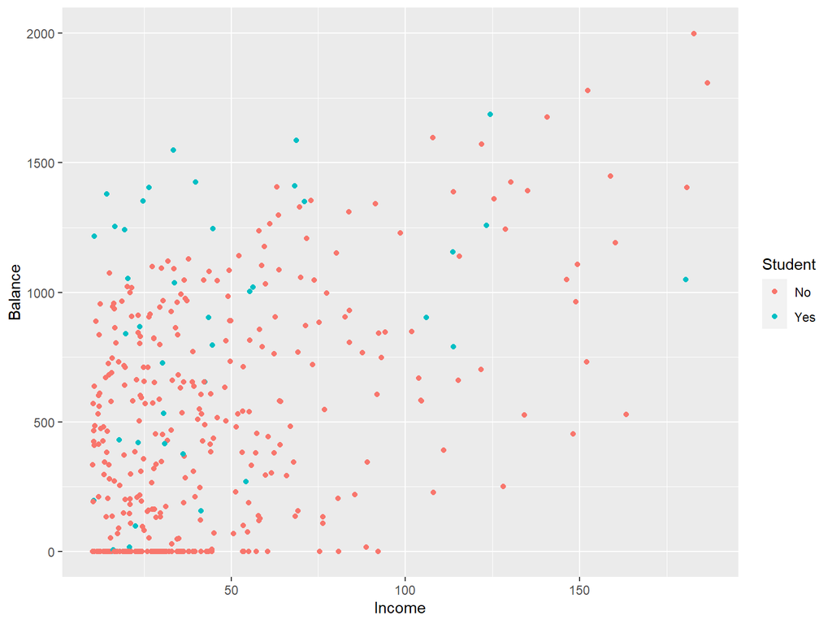

```r
ggplot() +
  geom_point(Credit, mapping = aes(x = Income, y = Balance, col = Student))
```

# Lab 3(b)

Balance ~ Income + Student

```r
Student_dummy <- rep(0, length(Student))
Student_dummy[Student=="Yes"] <- 1
Student_dummy[Student=="No"] <- 0
Student_dummy <- factor(Student_dummy)

lm.bal_inc_st <- lm(Balance ~ Student_dummy + Income)
summary(lm.bal_inc_st)
```

```
##
## Call:
## lm(formula = Balance ~ Student_dummy + Income)
##
## Residuals:
##     Min      1Q  Median      3Q     Max
## -762.37 -331.38  -45.04  323.60  818.28
##
## Coefficients:
##                Estimate Std. Error t value Pr(>|t|)
## (Intercept)    211.1430    32.4572   6.505 2.34e-10 ***
## Student_dummy1 382.6705    65.3108   5.859 9.78e-09 ***
## Income           5.9843     0.5566  10.751  < 2e-16 ***
## ---
## Signif. codes:  0 '***' 0.001 '**' 0.01 '*' 0.05 '.' 0.1 ' ' 1
##
## Residual standard error: 391.8 on 397 degrees of freedom
## Multiple R-squared:  0.2775, Adjusted R-squared:  0.2738
## F-statistic: 76.22 on 2 and 397 DF,  p-value: < 2.2e-16
```

```r
# or just use Student; R automatically does hot-encoding
lm.bal_inc_st <- lm(Balance ~ Student + Income)
summary(lm.bal_inc_st)
```

```
##
## Call:
## lm(formula = Balance ~ Student + Income)
##
## Residuals:
##     Min      1Q  Median      3Q     Max
## -762.37 -331.38  -45.04  323.60  818.28
##
## Coefficients:
##             Estimate Std. Error t value Pr(>|t|)
## (Intercept) 211.1430    32.4572   6.505 2.34e-10 ***
## StudentYes  382.6705    65.3108   5.859 9.78e-09 ***
## Income        5.9843     0.5566  10.751  < 2e-16 ***
## ---
## Signif. codes:  0 '***' 0.001 '**' 0.01 '*' 0.05 '.' 0.1 ' ' 1
##
## Residual standard error: 391.8 on 397 degrees of freedom
## Multiple R-squared:  0.2775, Adjusted R-squared:  0.2738
## F-statistic: 76.22 on 2 and 397 DF,  p-value: < 2.2e-16
```

# Lab 3(b)

Plot `lm(Balance ~ Income + Student)`

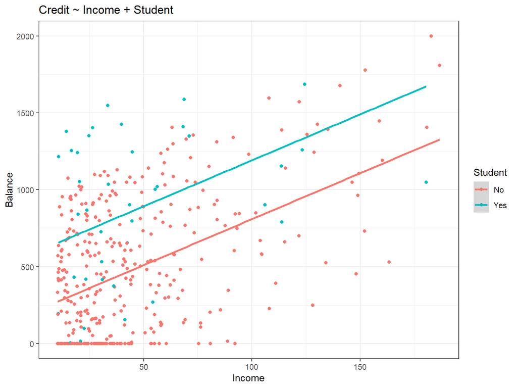

```r
plm <- lm(formula = Balance ~ Income + Student, data=Credit)

# plot with lm for outcome ~ pred + factor
ggplot(Credit, aes(x=Income, y=Balance, col=Student)) +
  geom_point() +
  geom_smooth(method = "lm", mapping=aes(y=predict(plm,Credit))) +
  ggtitle("Credit ~ Income + Student") +
  theme_bw()
```

# Lab 3(c)

Balance ~ Income*Student

```r
lm.bal_inc_st_inter <- lm(Balance ~ Income * Student_dummy)
summary(lm.bal_inc_st_inter)
```

```
##
## Call:
## lm(formula = Balance ~ Income * Student_dummy)
##
## Residuals:
##     Min      1Q  Median      3Q     Max
## -773.39 -325.70  -41.13  321.65  814.04
##
## Coefficients:
##                       Estimate Std. Error t value Pr(>|t|)
## (Intercept)           200.6232    33.6984   5.953 5.79e-09 ***
## Income                  6.2182     0.5921  10.502  < 2e-16 ***
## Student_dummy1        476.6758   104.3512   4.568 6.59e-06 ***
## Income:Student_dummy1  -1.9992     1.7313  -1.155    0.249
## ---
## Signif. codes:  0 '***' 0.001 '**' 0.01 '*' 0.05 '.' 0.1 ' ' 1
##
## Residual standard error: 391.6 on 396 degrees of freedom
## Multiple R-squared:  0.2799, Adjusted R-squared:  0.2744
## F-statistic:  51.3 on 3 and 396 DF,  p-value: < 2.2e-16
```

# Lab 3(c)

Balance ~ Student + Income:Student

```r
lm.bal_inc_st_inter <- lm(Balance ~ Student_dummy + Income:Student_dummy)
summary(lm.bal_inc_st_inter)
```

```
##
## Call:
## lm(formula = Balance ~ Student_dummy + Income:Student_dummy)
##
## Residuals:
##     Min      1Q  Median      3Q     Max
## -773.39 -325.70  -41.13  321.65  814.04
##
## Coefficients:
##                       Estimate Std. Error t value Pr(>|t|)
## (Intercept)           200.6232    33.6984   5.953 5.79e-09 ***
## Student_dummy1        476.6758   104.3512   4.568 6.59e-06 ***
## Student_dummy0:Income   6.2182     0.5921  10.502  < 2e-16 ***
## Student_dummy1:Income   4.2190     1.6269   2.593  0.00986 **
## ---
## Signif. codes:  0 '***' 0.001 '**' 0.01 '*' 0.05 '.' 0.1 ' ' 1
##
## Residual standard error: 391.6 on 396 degrees of freedom
## Multiple R-squared:  0.2799, Adjusted R-squared:  0.2744
## F-statistic:  51.3 on 3 and 396 DF,  p-value: < 2.2e-16
```

# Lab 3(c)

Compare with ANCOVA

```r
aov.bal_inc_st_inter <- aov(Balance ~ Income*Student)
aov.bal_inc_st <- aov(Balance ~ Student + Income)

anova(aov.bal_inc_st_inter, aov.bal_inc_st)
```

```
## Analysis of Variance Table
##
## Model 1: Balance ~ Income * Student
## Model 2: Balance ~ Student + Income
##   Res.Df      RSS Df Sum of Sq      F Pr(>F)
## 1    396 60734545
## 2    397 60939054 -1   -204509 1.3334 0.2489
```

# Lab 3(c)

Plot the full model

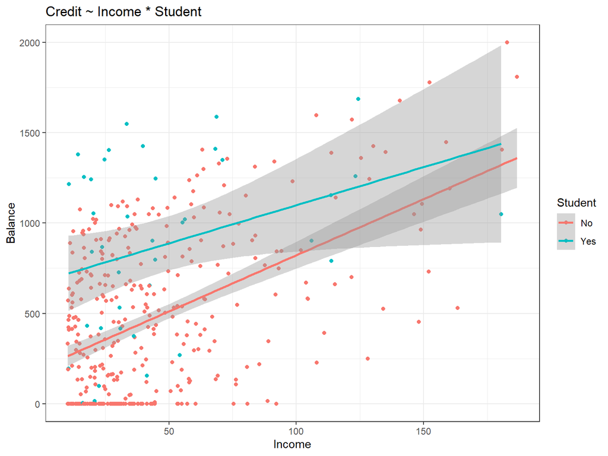

```r
ggplot(Credit, mapping=aes(x=Income, y=Balance, col=Student)) +
  geom_point() +
  geom_smooth(method = "lm") +
  ggtitle("Credit ~ Income * Student") +
  theme_bw()
```